# F1 Race Wins Analysis

Fasih Atif (2001385)

2020-12-14

F1 is a sport that is loved by millions of fans each year who love to watch it for its speed, technology, rivalries, and drama. Formula 1 recently completed its 70 years anniversary and last weekend ended the 2020 season with the Grand Finale at Abu Dhabi. Lewis Hamilton clinched his 7th world title equaling Michael Schumachers record. This got me thinking over who have been the best F1 drivers over the past 70 years. The metric that i chose to to measure success was number of race wins.

## **Web Scraping**

I scraped the data from the official website of [Formula One](https://www.formula1.com/en/results.html/2020/races.html) using the ‘rvest’ package. The website has a results page that lists the results for all seasons since 1950. The page lists one season at a time so to go on another seasons result, you need to select season year from the menu. Getting the result for one season was easy but to get all of the results for 70 years was quite hard. I experimented around with a for loop that inserted the season year into the URL and pulled out that seasons result using lapply function I was able to pull the data into a dataframe but it came out extremely messy. The values that belonged to one column were in another column in addition to abbreviations for driver names that also got scrapped. To clean the dataframe, i added an if else statement where if the column had any values, that data would be cleaned else a null value would be put in place. This fixed all the issues and my dataframe was able to come out clean and tidy.

Our dataframe for the race results from season of 1050- 2020 looks like the following:

| race_name | race_date | winner | team | laps |
| --- | --- | --- | --- | --- |
| Portugal | 25 Oct 2020 | Lewis Hamilton | Mercedes | 66 |
| Emilia Romagna | 01 Nov 2020 | Lewis Hamilton | Mercedes | 63 |
| Turkey | 15 Nov 2020 | Lewis Hamilton | Mercedes | 58 |
| Bahrain | 29 Nov 2020 | Lewis Hamilton | Mercedes | 57 |
| Sakhir | 06 Dec 2020 | Sergio Perez | Racing Point BWT Mercedes | 87 |
| Abu Dhabi | 13 Dec 2020 | Max Verstappen | Red Bull Racing Honda | 55 |

## Exploratory Data Analysis

### Top 5 most no of wins by F1 drivers (1950-2020)

We can check who have been the most successful drivers of all time using the visualization below:

[figure not shown]

### Top 5 most successful drivers winning progression over their career

We previously calculated the top 5 most successful drivers of all time. Now we will focus at the rate at which these 5 drivers gathered their race wins over the their racing careers:

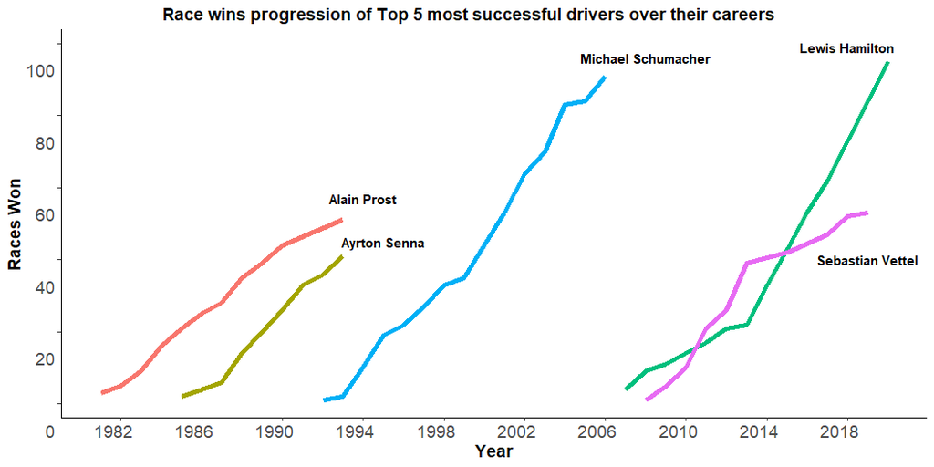

### **Racing Bar Chart Visualization for Most no of Wins by F1 Drivers (2015-2020)**

We will now take a subset of our results for 2015-2020 from our results database and visualize it using a racing bar chart to show how drivers rankings for most wins have changed over past 5 years.

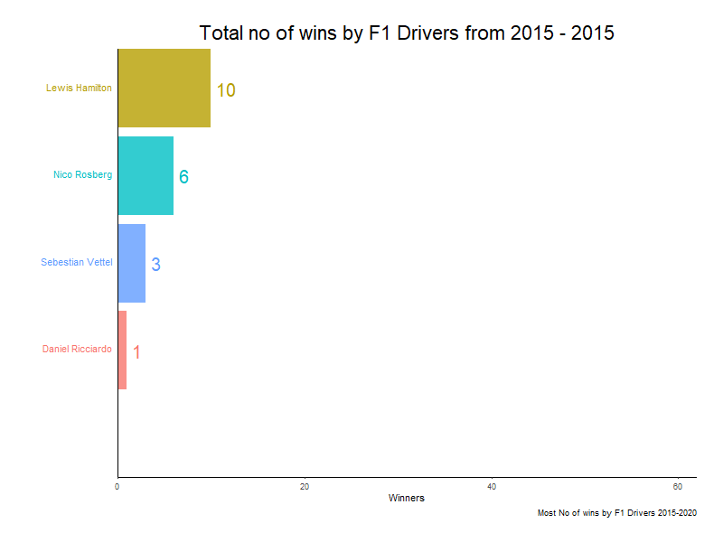

## **Summary**

I webscraped F1 race results from the past 70 seasons from the F1 website and cleaned the dataframe. Then we visualized the results via various graphs and found out that Lewis Hamilton is the most successful F1 driver in terms of race wins followed closely by Michael Schumacher. The top 5 most successful drivers had less wins in initial 2-3 years of their racing career but went on to dominate for the next 5-6 years. For race results since 2015, again Lewis Hamilton has showed his dominant form and has the highest number of wins followed by Nico Rosberg who although retired after 2016 season still ranks in 2nd place.